# Social _media_Regression

Deviprasad Saka

2024-04-13

```r
sm <- read.csv("D:/Multivariate Analysis/Social media regression/social_media_cleaned.csv")
str(sm)
```

```
## 'data.frame':    21 obs. of  10 variables:
##  $ character                    : chr  "masinl" "peace" "Patty" "Bunny" ...
##  $ Instagram                    : num  3.5 7.73 3.77 5.38 12 2.33 5.37 7 8.65 0.17 ...
##  $ LinkedIn                     : num  4 5.2 7 5.32 0.58 7 4 4 10 0 ...
##  $ SnapChat                     : num  1 3.68 0.53 1.3 0 0.47 0 3 3.83 0 ...
##  $ Twitter                      : num  5 0 0 0 0.67 0 0 0 0 0 ...
##  $ Whatsapp.Wechat              : num  1 4.18 9.83 5.3 3 12 6 10 6.15 1 ...
##  $ youtube                      : num  2.5 4.25 1.85 2 3.5 7 3 2 4 3 ...
##  $ OTT                          : num  14.5 0 2 2 2 3 0 3 3 0 ...
##  $ Reddit                       : num  2.5 0 0 0 1 0 0 0 0 0 ...
##  $ How.you.felt.the.entire.week.: int  3 3 4 4 3 5 4 4 3 2 ...
```

Multiple Regression

```r
sm2 <- sm[, 2:10]
sm2
```

```
##    Instagram LinkedIn SnapChat Twitter Whatsapp.Wechat youtube   OTT Reddit
## 1       3.50     4.00     1.00    5.00            1.00    2.50 14.50   2.50
## 2       7.73     5.20     3.68    0.00            4.18    4.25  0.00   0.00
## 3       3.77     7.00     0.53    0.00            9.83    1.85  2.00   0.00
## 4       5.38     5.32     1.30    0.00            5.30    2.00  2.00   0.00
## 5      12.00     0.58     0.00    0.67            3.00    3.50  2.00   1.00
## 6       2.33     7.00     0.47    0.00           12.00    7.00  3.00   0.00
## 7       5.37     4.00     0.00    0.00            6.00    3.00  0.00   0.00
## 8       7.00     4.00     3.00    0.00           10.00    2.00  3.00   0.00
## 9       8.65    10.00     3.83    0.00            6.15    4.00  3.00   0.00
## 10      0.17     0.00     0.00    0.00            1.00    3.00  0.00   0.00
## 11      4.58     2.13     0.42    2.42            1.00    1.00  0.00   0.00
## 12      3.33     2.50     0.33    2.83            3.67    2.50  1.50   0.00
## 13      5.30     1.52    14.87    0.00            4.02    0.54  0.51   0.01
## 14      6.00     3.00     1.00    1.00            3.42    2.50  1.00   0.00
```

[output cut: 29 more lines]

Q1.Model Development

```r
# Performing multiple regression on the dataset
fit <- lm(sm2$How.you.felt.the.entire.week. ~ Instagram + LinkedIn + SnapChat + Twitter + Whatsapp.Wechat + youtube + OTT + Reddit, data = sm2)

# Show the results
summary(fit)
```

```
##
## Call:
## lm(formula = sm2$How.you.felt.the.entire.week. ~ Instagram +
##     LinkedIn + SnapChat + Twitter + Whatsapp.Wechat + youtube +
##     OTT + Reddit, data = sm2)
##
## Residuals:
##      Min       1Q   Median       3Q      Max
## -1.14185 -0.32576 -0.04567  0.48445  1.49290
##
## Coefficients:
##                 Estimate Std. Error t value Pr(>|t|)
## (Intercept)      2.72737    0.67735   4.027  0.00168 **
## Instagram       -0.03076    0.06415  -0.480  0.64020
## LinkedIn         0.13054    0.08634   1.512  0.15646
## SnapChat         0.04201    0.06245   0.673  0.51384
## Twitter          0.16906    0.27175   0.622  0.54551
## Whatsapp.Wechat  0.05286    0.06754   0.783  0.44906
## youtube          0.03123    0.13553   0.230  0.82164
## OTT             -0.07857    0.09257  -0.849  0.41262
## Reddit          -0.03426    0.12296  -0.279  0.78526
## ---
## Signif. codes:  0 '***' 0.001 '**' 0.01 '*' 0.05 '.' 0.1 ' ' 1
##
## Residual standard error: 0.8173 on 12 degrees of freedom
## Multiple R-squared:  0.2807, Adjusted R-squared:  -0.1988
## F-statistic: 0.5853 on 8 and 12 DF,  p-value: 0.7725
```

The linear regression model predicts “How you felt the entire week?” based on social media usage variables including Instagram, LinkedIn, SnapChat, Twitter, Whatsapp/Wechat, youtube, OTT, and Reddit. Coefficients represent the estimated effect of each predictor variable on the response variable. However, most coefficients are not statistically significant at the 0.05 level, indicating weak evidence of association. The model explains approximately 28.07% of the variability in “How you felt the entire week?” as indicated by the multiple R-squared value. Nonetheless, the adjusted R-squared value is negative, suggesting potential issues with model fit or overfitting. The overall model is not statistically significant according to the F-statistic with a p-value of 0.7725.

```r
coefficients(fit)
```

```
##     (Intercept)       Instagram        LinkedIn        SnapChat         Twitter
##      2.72737269     -0.03076010      0.13053615      0.04201314      0.16905853
## Whatsapp.Wechat         youtube             OTT          Reddit
##      0.05285596      0.03122902     -0.07856775     -0.03426142
```

The coefficients represent the estimated impact of each social media platform on “How you felt the entire week?” The positive coefficients for LinkedIn, Twitter, Whatsapp/Wechat, and YouTube suggest a potential positive association with mood, while negative coefficients for Instagram, OTT, and Reddit imply a negative association. The intercept represents the estimated mood score when all predictors are zero.

```r
fitted(fit)
```

```
##        1        2        3        4        5        6        7        8
## 2.935205 3.676655 3.967639 3.496412 2.623704 4.206372 3.495158 3.515550
##        9       10       11       12       13       14       15       16
## 4.141847 2.868686 3.375386 3.597784 3.576427 3.325764 3.184138 3.507105
##       17       18       19       20       21
## 3.259870 3.045668 3.696969 3.275626 3.228034
```

Residual Analysis

```r
library(GGally)
```

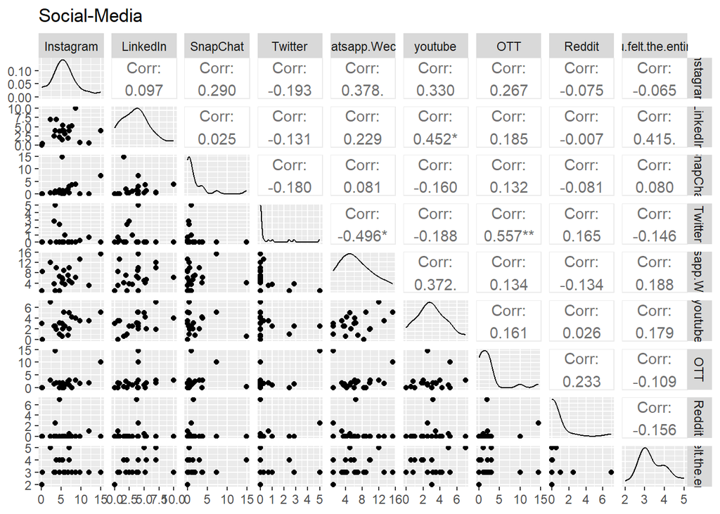

```r
ggpairs(data=sm2, title="Social-Media")
```